# Homework Assignment 1

Brendan Smith

January 28, 2016

**Objective Statement:** In this homework assignment, the goal is to familiarize ourselves with RStudio and RMarkdown given a dataset. We will apply some fundamental statistical analysis and plots utilizing built in R functions. The dataset provided is extracted from LiDAR data collected in the Sierra Nevada mountain range. Tree height and crown radii data was extracted through post processing. We are to import the data and test against the null hypothesis: Given tree height and crown radii, there will be zero correlation between the two.

**Methods:** First, the data is imported via the built-in `read.csv()` function. Next, a series data diagnostics are run to gather a general idea of the dataset, followed by the generation of histograms for the height and crown radii of the trees. Finally, the correlation between the tree height and crown radii is verified and presented. **Data:** The data utilized in this analysis was collected using Light Detection and Ranging (LiDAR) of the conifers that reside in the Sierra Nevada mountain range. The tree height, crown-radii, and location were exctracted from the initial LiDAR dataset. **Code:**

```r
#Read in the values from Trees.csv and place them in the variable "Trees"
Trees <- read.csv("./Trees.csv",header = TRUE,sep = ",")
#Use the attach() function in order to access the data arrays imported from Trees.csv with their inherited variable names from the header
attach(Trees)
#Assemble a data frame with the variables for good house-keeping purposes
Trees.data<-data.frame(OBJECTID, x, y, z.m., r.m.)
#Remove the variable "Trees"
rm(Trees)
```

```r
#Print a summary for the crown radii and tree height. This will provide the miniumum, first quartile, median, mean, third quartile and max values of the dataset.
#Summary of Crown Radii
summary(Trees.data$r.m.)
```

```
##    Min. 1st Qu.  Median    Mean 3rd Qu.    Max.
##  0.1847  1.5020  2.2420  2.5960  3.3190 12.0000
```

```r
#Summary of Tree Height
summary(Trees.data$z.m.)
```

```
##    Min. 1st Qu.  Median    Mean 3rd Qu.    Max.
##   2.000   6.155  10.900  13.910  17.780  73.930
```

**Results:**

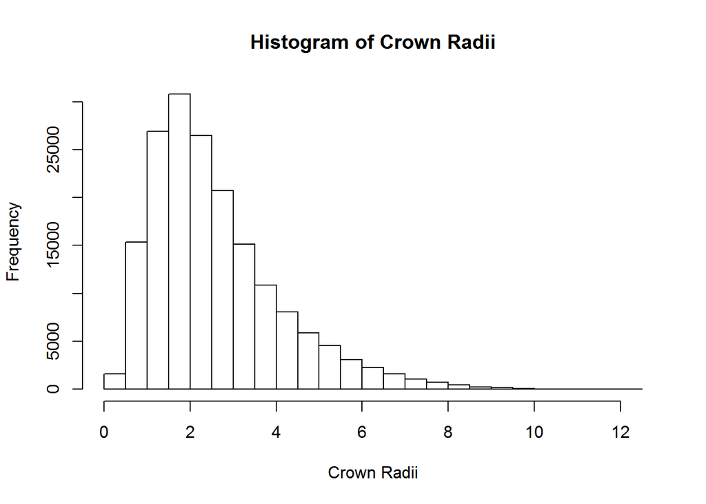

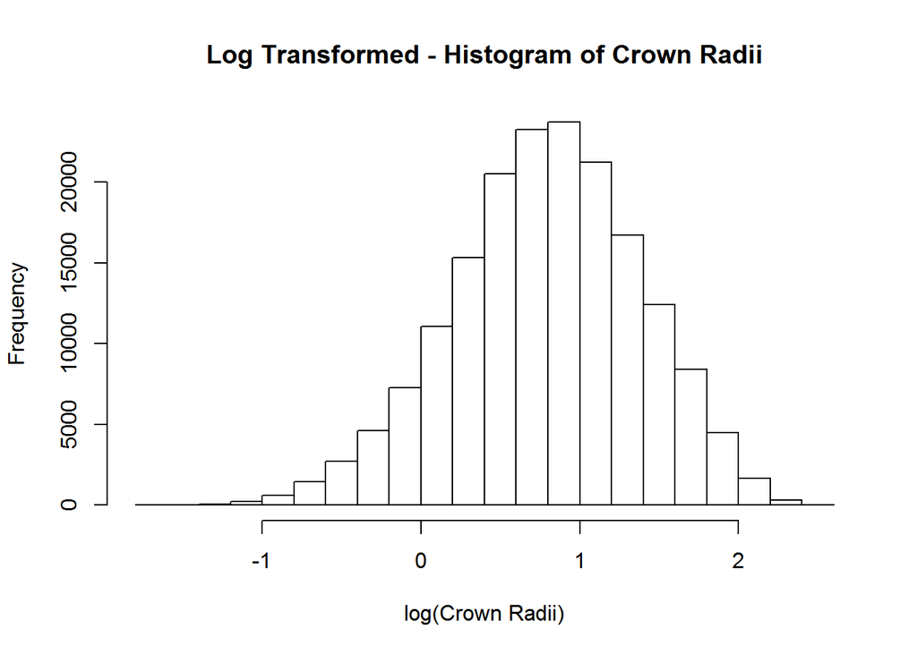

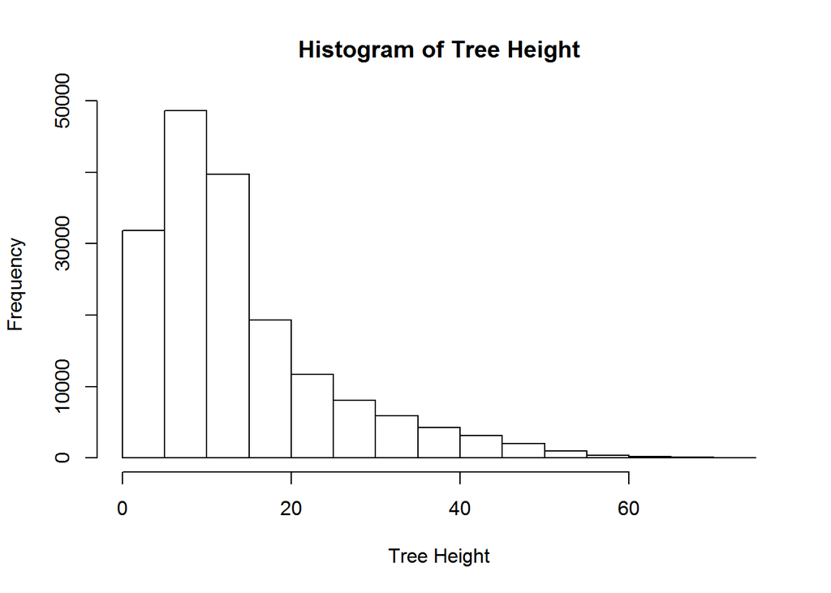

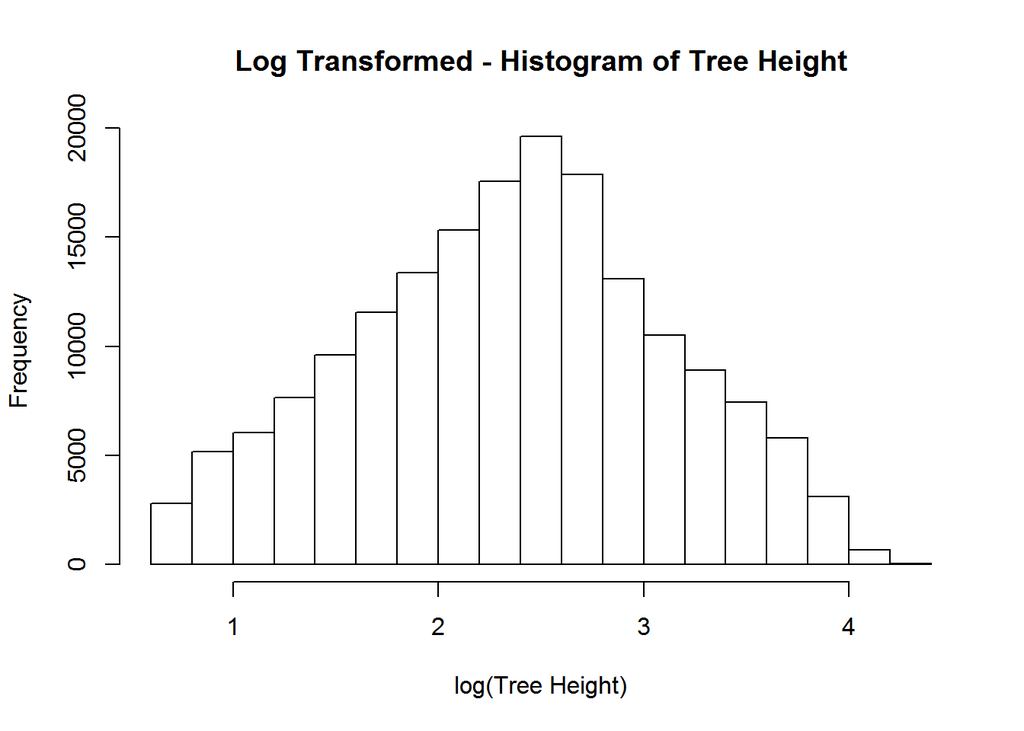

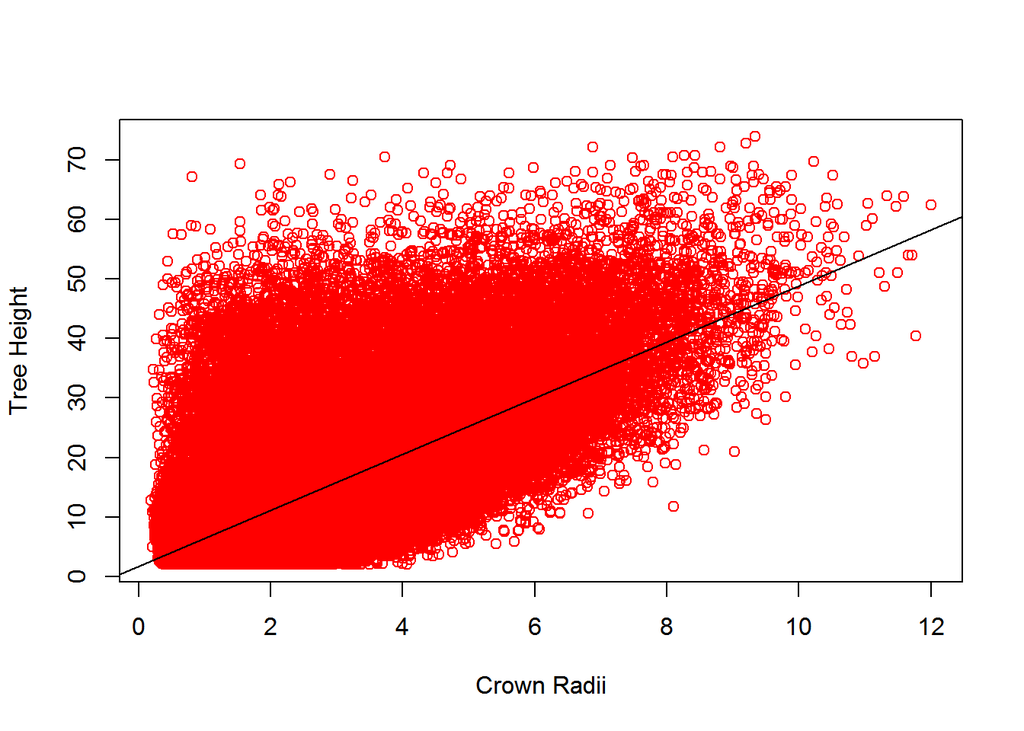

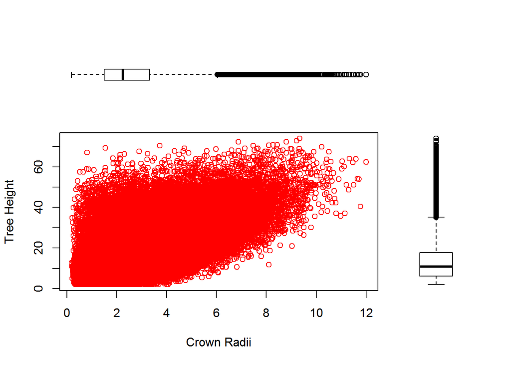

**Discussion:**

The calculated Pearson’s correlation coefficient, or r-value, is 0.6613456. This means that we have a strong positive correlation between the tree-crown radii and height, which is to be expected. This also confirms that we can reject the null hypothesis that there is no correlation between tree-crown radii and height.

**Limitations:** The most notable limitations to RMarkdown is the fact that you cannot underline or right-justify text. In terms of the data, the crown density is not taken into account when performing this analysis, and therefore could be considered an incomplete analysis.